# Case Study 1: Beers and Breweries

Shikha Pandey

October 6, 2021

## Loading Libraries and setting the theme for plots

```r
library(dplyr)
library(tidyr)
library(tidyverse)
library(ggplot2)
library(stringi)
library(stringr)
library(naniar)
library(maps)
library(mapproj)
library(mice) #mice
library(class) #knn
library(caret) #confusionMatrix
library(e1071) #Naive Bayes
theme_set(theme_classic()) #Set the theme for plots
```

## Read in both Beer and Brewery files related to this case study.

```r
#Read in data from Beers.csv
Beers = read.csv(file.choose(),header = TRUE, na.strings = c(""," ","NA"))
#Read in data from Breweries.csv
Breweries = read.csv(file.choose(),header = TRUE, na.strings = c(""," ","NA"))
Breweries$State = as.factor(str_remove_all(Breweries$State, "\\s")) #Remove space preceeding State
```

```r
dim(Beers)
```

```
## [1] 2410    7
```

```r
#Beer data has 2410 observations and 7 columns:

#1. Name: Name of the beer
#2. Beer_ID: Unique identifier of the beer
#3. ABV: Alcohol by volume of the beer
#4. IBU: International Bitterness Units of the beer
#5. Brewery_id: Brewery identifier associated with the beer
#6. Style: Style of the beer
#7. Ounces: Ounces of the beer
```

```r
dim(Breweries)
```

```
## [1] 558   4
```

```r
#Breweries data has 558 observations and 4 columns:

#1. Brew_ID: Unique identifier of the brewery
#2. Name: Name of the brewery
#3. City: City where brewery is located
#4. State: U.S. State where brewery is located
```

##1. Number of breweries present in each state.

```r
#Number of breweries by state
Breweries %>% group_by(State) %>% summarize(Count = n()) %>% arrange(desc(Count)) %>% print(n=Inf)
```

```
## # A tibble: 51 x 2
##    State Count
##    <fct> <int>
##  1 CO       47
##  2 CA       39
##  3 MI       32
##  4 OR       29
##  5 TX       28
##  6 PA       25
##  7 MA       23
##  8 WA       23
##  9 IN       22
## 10 WI       20
## 11 NC       19
## 12 IL       18
```

[output cut: 39 more lines]

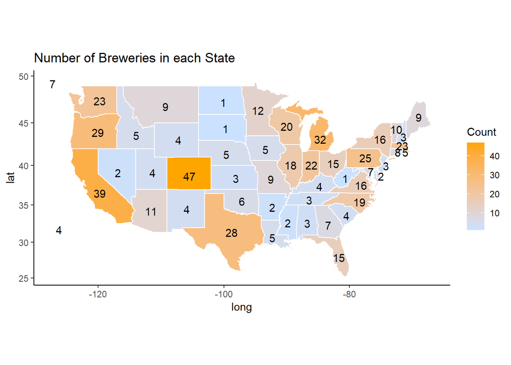

```r
#Plot the map of all States in dataset with gradient color based on count of breweries
lookup = data.frame(State_Cd = state.abb, State = state.name) #makes a data frame with State name and state code
colnames(Breweries)[4] = "State_Cd" # Change Column Name
Breweries2 = merge(Breweries,lookup,"State_Cd") #make one dataset with state names and abb
BreweriesMapData = count(Breweries2,State) #count up the occurance of each state.
colnames(BreweriesMapData)[2] = "Count" #change "n" to "Count"
BreweriesMapData$region <- tolower(BreweriesMapData$State)
BreweriesMapData2 = BreweriesMapData[-1]
states <- map_data("state")
map.df <- merge(states,BreweriesMapData2, by="region", all.x=T)
map.df <- map.df[order(map.df$order),]
Num_pos <- data.frame(region=tolower(state.name), long=state.center$x, lat=state.center$y)
Num_pos <- merge(Num_pos, BreweriesMapData2, by="region", all.x = TRUE)
#Plot
ggplot(map.df, aes(x=long,y=lat))+
  geom_polygon(aes(group=group, fill=Count),colour="white")+
  geom_text(data=Num_pos, aes(long, lat, label=Count)) +
  scale_fill_gradient(low = "lightsteelblue1",
                      high = "Orange",
                      guide = "colourbar")+
  ggtitle("Number of Breweries in each State") +
  coord_map()
```

```r
#There are total 558 breweries in the US. CO has the most with 47 breweries. DC, ND, SD and WV are at the bottom with 1 brewery each.
```

##2. Merge beer data with the breweries data. First 6 observations and the last 6 observations printed to check the merged file.

```r
#Merge the data frames for Beers and Breweries
Budweiser = merge(Beers,Breweries, by.x = "Brewery_id", by.y = "Brew_ID")
#Assigning new names to the columns of the data frame
colnames(Budweiser) <- c('Brewery_ID','Beer','Beer_ID', 'ABV', 'IBU', 'Style', 'Ounces', 'Brewery', 'City', 'State')
#Rearranging columns in data frame
Budweiser = Budweiser %>% select(Brewery_ID, Brewery, Beer_ID, Beer, ABV, IBU, Style, Ounces, City, State)
str(Budweiser)
```

```
## 'data.frame':    2410 obs. of  10 variables:
##  $ Brewery_ID: int  1 1 1 1 1 1 2 2 2 2 ...
##  $ Brewery   : Factor w/ 551 levels "10 Barrel Brewing Company",..: 355 355 355 355 355 355 12 12 12 12 ...
##  $ Beer_ID   : int  2692 2691 2690 2689 2688 2687 2686 2685 2684 2683 ...
##  $ Beer      : Factor w/ 2305 levels "#001 Golden Amber Lager",..: 802 1258 2185 1640 1926 1525 458 1218 43 71 ...
##  $ ABV       : num  0.045 0.049 0.048 0.06 0.06 0.056 0.08 0.125 0.077 0.042 ...
##  $ IBU       : int  50 26 19 38 25 47 68 80 25 42 ...
##  $ Style     : Factor w/ 99 levels "Abbey Single Ale",..: 15 76 47 82 21 56 11 45 76 17 ...
##  $ Ounces    : num  16 16 16 16 16 16 16 16 16 16 ...
##  $ City      : Factor w/ 384 levels "Abingdon","Abita Springs",..: 228 228 228 228 228 228 200 200 200 200 ...
##  $ State     : Factor w/ 51 levels "AK","AL","AR",..: 24 24 24 24 24 24 18 18 18 18 ...
```

```r
#First 6 observations of merged dataset
head(Budweiser)
```

```
##   Brewery_ID            Brewery Beer_ID          Beer   ABV IBU
## 1          1 NorthGate Brewing     2692  Get Together 0.045  50
## 2          1 NorthGate Brewing     2691 Maggie's Leap 0.049  26
## 3          1 NorthGate Brewing     2690    Wall's End 0.048  19
## 4          1 NorthGate Brewing     2689       Pumpion 0.060  38
## 5          1 NorthGate Brewing     2688    Stronghold 0.060  25
## 6          1 NorthGate Brewing     2687   Parapet ESB 0.056  47
##                                 Style Ounces        City State
## 1                        American IPA     16 Minneapolis    MN
## 2                  Milk / Sweet Stout     16 Minneapolis    MN
## 3                   English Brown Ale     16 Minneapolis    MN
## 4                         Pumpkin Ale     16 Minneapolis    MN
## 5                     American Porter     16 Minneapolis    MN
## 6 Extra Special / Strong Bitter (ESB)     16 Minneapolis    MN
```

```r
#Last 6 observations of merged dataset
tail(Budweiser)
```

```
##      Brewery_ID                       Brewery Beer_ID                      Beer
## 2405        556         Ukiah Brewing Company      98             Pilsner Ukiah
## 2406        557       Butternuts Beer and Ale      52  Heinnieweisse Weissebier
## 2407        557       Butternuts Beer and Ale      51           Snapperhead IPA
## 2408        557       Butternuts Beer and Ale      50         Moo Thunder Stout
## 2409        557       Butternuts Beer and Ale      49         Porkslap Pale Ale
## 2410        558 Sleeping Lady Brewing Company      30 Urban Wilderness Pale Ale
##        ABV IBU                   Style Ounces          City State
## 2405 0.055  NA         German Pilsener     12         Ukiah    CA
## 2406 0.049  NA              Hefeweizen     12 Garrattsville    NY
## 2407 0.068  NA            American IPA     12 Garrattsville    NY
## 2408 0.049  NA      Milk / Sweet Stout     12 Garrattsville    NY
## 2409 0.043  NA American Pale Ale (APA)     12 Garrattsville    NY
## 2410 0.049  NA        English Pale Ale     12     Anchorage    AK
```

```r
#After merging the beers and breweries datasets based on Brewery_ID from beers dataset and Brew_ID from breweries dataset, resulting dataset, Budweiser, now has 2410 observations with 10 columns.
#Head of the dataset displays first 6 rows of data and tail of dataset displays last 6 rows of data from this merged dataset.
```

##3. Addressing the missing values in each column.

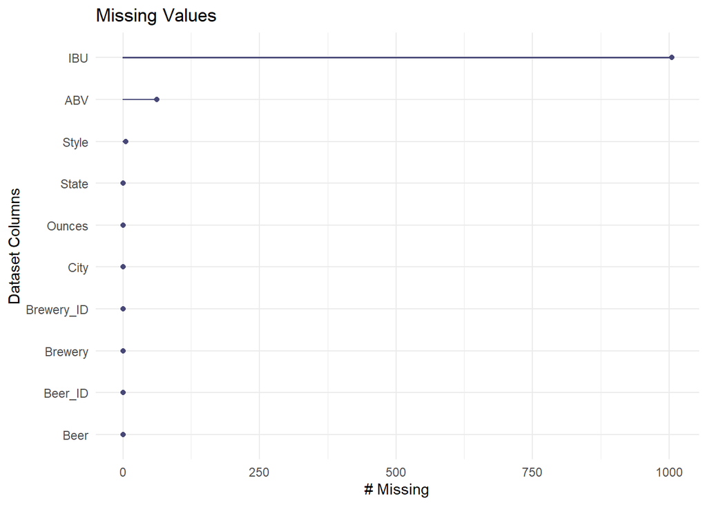

```r
#Looking for missing values in dataset
gg_miss_var(Budweiser) + labs(title = 'Missing Values', x = 'Dataset Columns')
```

```r
sapply(Budweiser, function(x) sum(is.na(x)))
```

```
## Brewery_ID    Brewery    Beer_ID       Beer        ABV        IBU      Style
##          0          0          0          0         62       1005          5
##     Ounces       City      State
##          0          0          0
```

```r
#Missing values are found for IBU (1005), ABV (62) and Style (5). It is a significant number for IBU (41.7%), notable for ABV (2.57%) but insignificant for Style (0.2%), so, I decided to exclude the missing 'Style' data (5 rows) from Budweiser.
```

```r
#Excluding missing data for 'Style'
Budweiser = Budweiser %>% filter(!is.na(Style))
sapply(Budweiser, function(x) sum(is.na(x)))
```

```
## Brewery_ID    Brewery    Beer_ID       Beer        ABV        IBU      Style
##          0          0          0          0         59       1002          0
##     Ounces       City      State
##          0          0          0
```

```r
#After excluding 5 rows of missing 'Style' data, I notice that missing IBU and ABV are 1002 and 59 respectively as compared to 1005 and 62 earlier.
```

```r
#Assumption is that missing values of ABV and IBU are Missing At Random (MAR). Applying multiple imputation with function MICE() for ABV and IBU with covariant 'Style'.

#Multiple imputation for missing values of ABV and IBU
mice_mod <- mice(Budweiser[, c("IBU","Style")], method='pmm')
mice_complete1 <- complete(mice_mod)

mice_mod <- mice(Budweiser[, c("ABV","Style")], method='pmm')
mice_complete2 <- complete(mice_mod)

#Transfer the predicted missing values for ABV and IBU into the Budweiser dataset
Budweiser$IBU = mice_complete1$IBU
Budweiser$ABV = mice_complete2$ABV
```

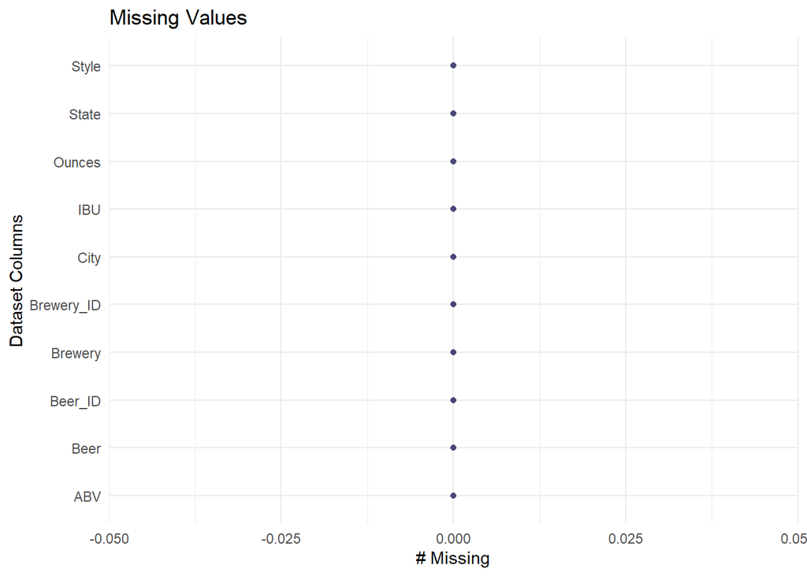

```r
#Looking for missing values in dataset after imputation, none found
gg_miss_var(Budweiser) + labs(title = 'Missing Values', x = 'Dataset Columns')
```

```r
sapply(Budweiser, function(x) sum(is.na(x)))
```

```
## Brewery_ID    Brewery    Beer_ID       Beer        ABV        IBU      Style
##          0          0          0          0          0          0          0
##     Ounces       City      State
##          0          0          0
```

```r
#With these imputed values, dataset is now complete with no more missing values.
```

##4. Median alcohol content and international bitterness unit for each state. Bar chart plots to compare.

```r
#Median acohol content and international bitterness unit for each state
Budweiser %>% group_by(State) %>% summarize(medianABV = median(ABV), medianIBU = median(IBU), Count = n()) %>% print(n=Inf)
```

```
## # A tibble: 51 x 4
##    State medianABV medianIBU Count
##    <fct>     <dbl>     <dbl> <int>
##  1 AK       0.056       32      25
##  2 AL       0.06        39.5    10
##  3 AR       0.052       33       5
##  4 AZ       0.056       26      46
##  5 CA       0.058       40     183
##  6 CO       0.06        37     263
##  7 CT       0.06        40      27
##  8 DC       0.0625      32.5     8
##  9 DE       0.0575      56       2
## 10 FL       0.0555      36      58
## 11 GA       0.055       36.5    16
## 12 HI       0.054       22      27
```

[output cut: 39 more lines]